# STAT 432 Homework 01

Spring 2018 | Dalpiaz | UIUC

Due:** Friday, February 2, 11:59 PM

```r
library(tibble)
library(readr)

# define data generating process
make_hw01_data = function(n_obs = 100) {
  x = runif(n = n_obs, min = -1.5, max = 1)
  y = rnorm(n = n_obs, mean = 3 * x ^ 2 + x ^ 5, sd = 0.5)
  data.frame(y, x)
}

# generate datasets
set.seed(42)
hw01_trn_data = make_hw01_data(n_obs = 100)
hw01_tst_data = make_hw01_data(n_obs = 500)

# write to files
write_csv(hw01_trn_data, "hw01-trn-data.csv")
write_csv(hw01_tst_data, "hw01-tst-data.csv")

# clean up
rm(hw01_trn_data)
rm(hw01_tst_data)
```

This homework will use data in `hw01-trn-data.csv` and `hw01-tst-data.csv` which are train and test datasets respectively. Both datasets contain a single predictor `x` and a numeric response `y`. The following chunk imports this data.

```r
hw01_trn_data = read.csv("hw01-trn-data.csv")
hw01_tst_data = read.csv("hw01-tst-data.csv")
```

For this assignment, you may only use the following packages:

```r
library(FNN)
library(rpart)
library(knitr)
library(kableExtra)
```

## Exercise 1 (Polynomial Models)

Fit a total of five polynomial models to the training data that can be used to predict `y` from `x`. Use polynomial degrees of 1, 3, 5, 7, and 9. For each, calculate both train and test RMSE. Do not output these results directly, instead summarize the results with a single well labeled plot that shows both train and test RMSE as a function of the degree of the polynomial fit.

**Solution:**

```r
# fit poly models
poly_mod_1 = lm(y ~ poly(x, 1), data = hw01_trn_data)
poly_mod_3 = lm(y ~ poly(x, 3), data = hw01_trn_data)
poly_mod_5 = lm(y ~ poly(x, 5), data = hw01_trn_data)
poly_mod_7 = lm(y ~ poly(x, 7), data = hw01_trn_data)
poly_mod_9 = lm(y ~ poly(x, 9), data = hw01_trn_data)
```

```r
# helper function for RMSE
calc_rmse = function(actual, predicted) {
  sqrt(mean((actual - predicted) ^ 2))
}
```

```r
# poly model training RMSE
poly_trn_rmse = c(calc_rmse(hw01_trn_data$y, predict(poly_mod_1, hw01_trn_data)),
                  calc_rmse(hw01_trn_data$y, predict(poly_mod_3, hw01_trn_data)),
                  calc_rmse(hw01_trn_data$y, predict(poly_mod_5, hw01_trn_data)),
                  calc_rmse(hw01_trn_data$y, predict(poly_mod_7, hw01_trn_data)),
                  calc_rmse(hw01_trn_data$y, predict(poly_mod_9, hw01_trn_data)))

# poly model testing RMSE
poly_tst_rmse = c(calc_rmse(hw01_tst_data$y, predict(poly_mod_1, hw01_tst_data)),
                  calc_rmse(hw01_tst_data$y, predict(poly_mod_3, hw01_tst_data)),
                  calc_rmse(hw01_tst_data$y, predict(poly_mod_5, hw01_tst_data)),
                  calc_rmse(hw01_tst_data$y, predict(poly_mod_7, hw01_tst_data)),
                  calc_rmse(hw01_tst_data$y, predict(poly_mod_9, hw01_tst_data)))
```

```r
# summarize results
poly_results = data.frame(
  degree = c(1, 3, 5, 7, 9),
  trn_rmse = poly_trn_rmse,
  tst_rmse = poly_tst_rmse
)
```

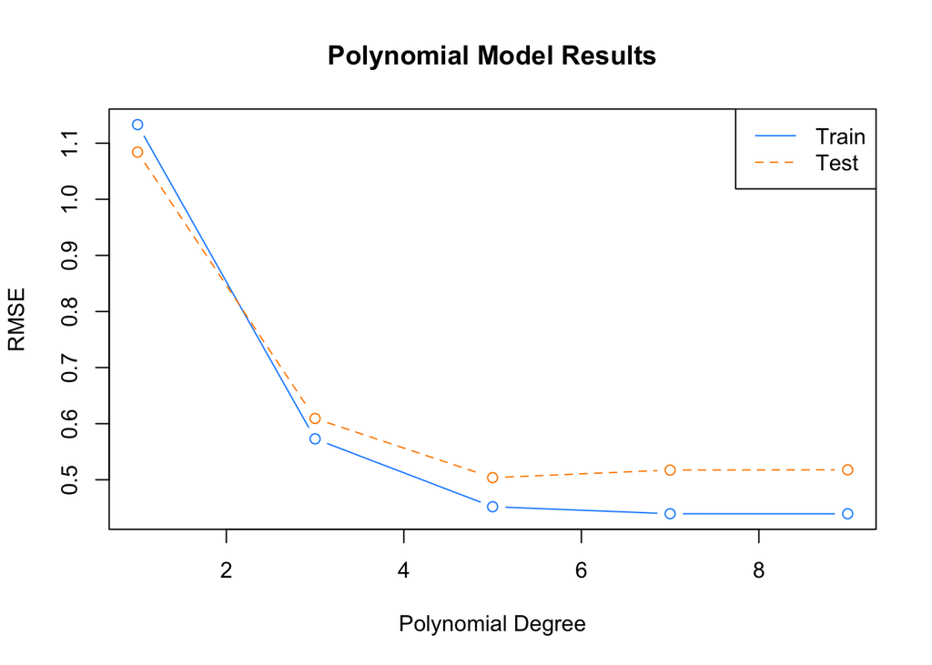

## Exercise 2 (KNN Models)

Fit a total of five KNN models to the training data that can be used to predict `y` from `x`. Use `k` (number of neighbors) values of `1`, `11`, `21`, `31`, and `41`. For each, calculate both train and test RMSE. Do not output these results directly, instead summarize the results with using a well-formatted markdown table that shows `k`, train RMSE and test RMSE.

**Solution:**

```r
# fit knn models, predict on train datat
knn_mod_01_trn = knn.reg(train = hw01_trn_data["x"], y = hw01_trn_data["y"],
                         test  = hw01_trn_data["x"], k =  1)
knn_mod_11_trn = knn.reg(train = hw01_trn_data["x"], y = hw01_trn_data["y"],
                         test  = hw01_trn_data["x"], k = 11)
knn_mod_21_trn = knn.reg(train = hw01_trn_data["x"], y = hw01_trn_data["y"],
                         test  = hw01_trn_data["x"], k = 21)
knn_mod_31_trn = knn.reg(train = hw01_trn_data["x"], y = hw01_trn_data["y"],
                         test  = hw01_trn_data["x"], k = 31)
knn_mod_41_trn = knn.reg(train = hw01_trn_data["x"], y = hw01_trn_data["y"],
                         test  = hw01_trn_data["x"], k = 41)
```

```r
# fit knn models, predict on test datat
knn_mod_01_tst = knn.reg(train = hw01_trn_data["x"], y = hw01_trn_data["y"],
                         test  = hw01_tst_data["x"], k =  1)
knn_mod_11_tst = knn.reg(train = hw01_trn_data["x"], y = hw01_trn_data["y"],
                         test  = hw01_tst_data["x"], k = 11)
knn_mod_21_tst = knn.reg(train = hw01_trn_data["x"], y = hw01_trn_data["y"],
                         test  = hw01_tst_data["x"], k = 21)
knn_mod_31_tst = knn.reg(train = hw01_trn_data["x"], y = hw01_trn_data["y"],
                         test  = hw01_tst_data["x"], k = 31)
knn_mod_41_tst = knn.reg(train = hw01_trn_data["x"], y = hw01_trn_data["y"],
                         test  = hw01_tst_data["x"], k = 41)
```

```r
# knn model training RMSE
knn_trn_rmse = c(calc_rmse(hw01_trn_data$y, knn_mod_01_trn$pred),
                 calc_rmse(hw01_trn_data$y, knn_mod_11_trn$pred),
                 calc_rmse(hw01_trn_data$y, knn_mod_21_trn$pred),
                 calc_rmse(hw01_trn_data$y, knn_mod_31_trn$pred),
                 calc_rmse(hw01_trn_data$y, knn_mod_41_trn$pred))

# knn model testing RMSE
knn_tst_rmse = c(calc_rmse(hw01_tst_data$y, knn_mod_01_tst$pred),
                 calc_rmse(hw01_tst_data$y, knn_mod_11_tst$pred),
                 calc_rmse(hw01_tst_data$y, knn_mod_21_tst$pred),
                 calc_rmse(hw01_tst_data$y, knn_mod_31_tst$pred),
                 calc_rmse(hw01_tst_data$y, knn_mod_41_tst$pred))
```

| k | Train RMSE | Test RMSE |
| --- | --- | --- |
| 1 | 0.000 | 0.718 |
| 11 | 0.504 | 0.557 |
| 21 | 0.719 | 0.634 |
| 31 | 0.841 | 0.716 |
| 41 | 0.954 | 0.833 |

## Exercise 3 (Tree Models)

Fit a total of five tree models to the training data that can be used to predict `y` from `x`. To do so, use the `rpart()` function from the `rpart` package. The `rpart()` syntax is very similar to `lm()`. For example:

```r
rpart(y ~ x, data = some_data, control = rpart.control(cp = 0.5, minsplit = 2))
```

This code fits a tree with a cost complexity parameter of `0.5`, as defined using the `cp` argument to `rpart.control`. We will consider this to be the single tuning parameter of tree fitting. (More on this much later in the course.) The `minsplit` argument could also be considered a tuning parameter, but we will keep it fixed at 2.

Use `cp` values of `0`, `0.001`, `0.01`, `0.1`, and `1`. For each, calculate both train and test RMSE. Do not output these results directly, instead summarize the results with using a well-formatted markdown table that shows `cp`, train RMSE and test RMSE.

**Solution:**

```r
# fit tree models
tree_mod_0000 = rpart(y ~ x, data = hw01_trn_data, control = rpart.control(cp = 0.000, minsplit = 2))
tree_mod_0001 = rpart(y ~ x, data = hw01_trn_data, control = rpart.control(cp = 0.001, minsplit = 2))
tree_mod_0010 = rpart(y ~ x, data = hw01_trn_data, control = rpart.control(cp = 0.010, minsplit = 2))
tree_mod_0100 = rpart(y ~ x, data = hw01_trn_data, control = rpart.control(cp = 0.100, minsplit = 2))
tree_mod_1000 = rpart(y ~ x, data = hw01_trn_data, control = rpart.control(cp = 1.000, minsplit = 2))
```

```r
# poly model training RMSE
tree_trn_rmse = c(calc_rmse(hw01_trn_data$y, predict(tree_mod_0000, hw01_trn_data)),
                  calc_rmse(hw01_trn_data$y, predict(tree_mod_0001, hw01_trn_data)),
                  calc_rmse(hw01_trn_data$y, predict(tree_mod_0010, hw01_trn_data)),
                  calc_rmse(hw01_trn_data$y, predict(tree_mod_0100, hw01_trn_data)),
                  calc_rmse(hw01_trn_data$y, predict(tree_mod_1000, hw01_trn_data)))

# poly model testing RMSE
tree_tst_rmse = c(calc_rmse(hw01_tst_data$y, predict(tree_mod_0000, hw01_tst_data)),
                  calc_rmse(hw01_tst_data$y, predict(tree_mod_0001, hw01_tst_data)),
                  calc_rmse(hw01_tst_data$y, predict(tree_mod_0010, hw01_tst_data)),
                  calc_rmse(hw01_tst_data$y, predict(tree_mod_0100, hw01_tst_data)),
                  calc_rmse(hw01_tst_data$y, predict(tree_mod_1000, hw01_tst_data)))
```

| cp | Train RMSE | Test RMSE |
| --- | --- | --- |
| 0.000 | 0.000 | 0.718 |
| 0.001 | 0.187 | 0.677 |
| 0.010 | 0.425 | 0.609 |
| 0.100 | 0.646 | 0.697 |
| 1.000 | 1.192 | 1.049 |

## Exercise 4 (Visualizing Results)

Add lines (curves) to the following plot which correspond to the fitted model for the best polynomial model, best KNN model, and best tree model based on the results of the previous exercises. Use different line types and colors for the different models. Add a legend to indicate which line is which model.

**Solution:**

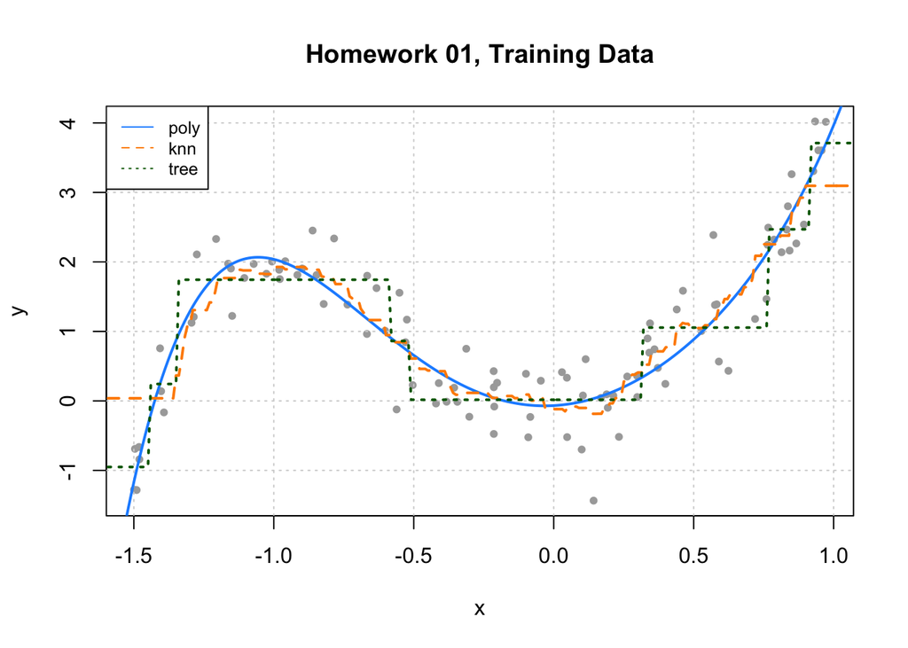

```r
plot_grid = data.frame(x = seq(from = min(hw01_trn_data$x) - 0.5,
                               to   = max(hw01_trn_data$x) + 0.5,
                               by   = 0.01))

poly_pred = predict(poly_mod_5, plot_grid)
knn_pred  = knn.reg(train = hw01_trn_data["x"], y = hw01_trn_data["y"],
                    test = plot_grid["x"], k = 11)$pred
tree_pred = predict(tree_mod_0010, plot_grid)

plot(y ~ x, data = hw01_trn_data, col = "darkgrey", pch = 20,
     main = "Homework 01, Training Data")
grid()
lines(plot_grid$x, poly_pred, col = "dodgerblue", lty = 1, lwd = 2)
lines(plot_grid$x, knn_pred,  col = "darkorange", lty = 2, lwd = 2)
lines(plot_grid$x, tree_pred, col = "darkgreen",  lty = 3, lwd = 2)
legend("topleft", c("poly", "knn", "tree"), lty = c(1, 2, 3), lwd = 1,
       col = c("dodgerblue", "darkorange", "darkgreen"), cex = 0.8)
```

## Exercise 5 (Concept Checks)

**(a)** Which, if any, of the polynomial models are likely **underfitting** based on the results you obtained?

**Solution:** Since `degree = 5` has the lowest test RMSE, we believe **`degree = 1`** and **`degree = 3`** maybe be underfitting as they are less flexible.

**(b)** Which, if any, of the polynomial models are likely **overfitting** based on the results you obtained?

**Solution:** Since `degree = 5` has the lowest test RMSE, we believe **`degree = 7`** and **`degree = 9`** maybe be overfitting as they are more flexible.

**(c)** Which, if any, of the KNN models are likely **underfitting** based on the results you obtained?

**Solution:** `k = 21`, `k = 31`, `k = 41`

**(d)** Which, if any, of the KNN models are likely **overfitting** based on the results you obtained?

**Solution:** `k = 1`

**(e)** Which, if any, of the tree models are likely **underfitting** based on the results you obtained?

**Solution:** `cp = 0.1`, `cp = 1.000`

**(f)** Which, if any, of the tree models are likely **overfitting** based on the results you obtained?

**Solution:** `cp = 0.000`, `cp = 0.001`